# What Causes Delay on Auckland Transport

My experience with the tardiness of Auckland Transport

Ellie

## What’s going on with this data?

As an avid user of public transport, I wanted to figure out the effects of different variables on how late the public transport was. From this information I can hopefully have better judgement on If I should sleep that extra minute or not.

(please note: not all data came from me, I had help from friends and my sister)

## How late public Transport is in general

The first thing I wanted to know is how on time the public transport system is in general.

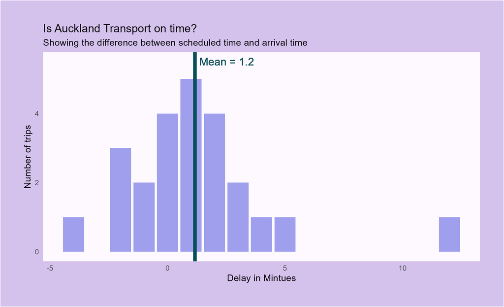

From this I found that the delay in this part of the year was much better than from when I did this in March, also that our mean amount of delay is 1.2 minutes.

However for my quest of perfecting the least amount of wait time at a bus stop, this doesn’t tell me enough.

So what else could effect Public Transport tardiness?

## Does the day of the week effect delay?

I wanted to know if I traveled on a Friday, would there be more likely of a delay compared to a Tuesday. Since I think people are more likely to stay and work from home on a Friday I believed that there would be more delay on the middle days

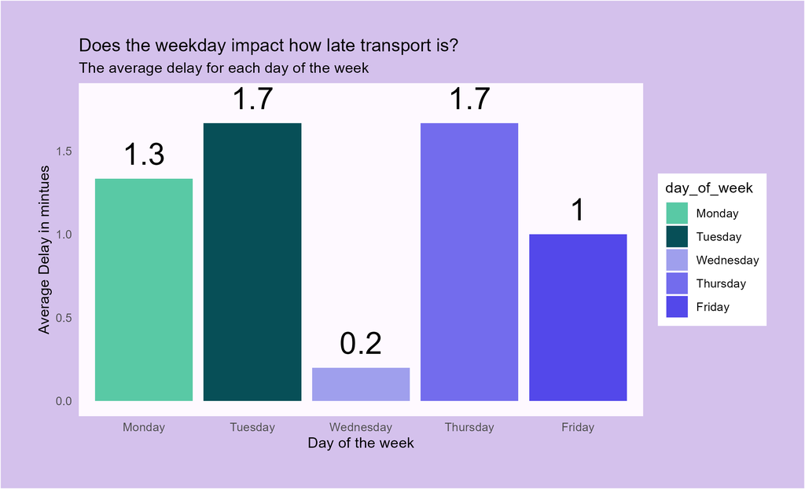

A bar chart showing the averages of delay depending on day of week

I take public transport all times of the day, would that effect the delay?

## Does the time you Travel Impact the delay

With the morning and evening rush I expected there to be some effect on the delay

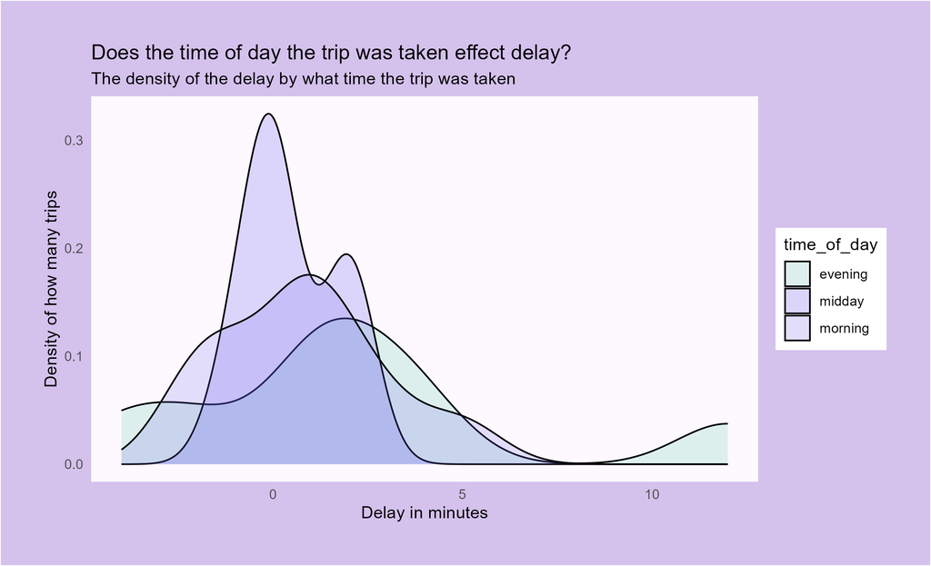

A density graph of the time of day and delay

As I expected, There is definitely an effect on the delay from what times it was taken, however I definitely thought there would be more of a effect.

Would the route I take have an effect?

## Effect of route on Delay

Since different routes experience different conditions would that impact there tardiness?

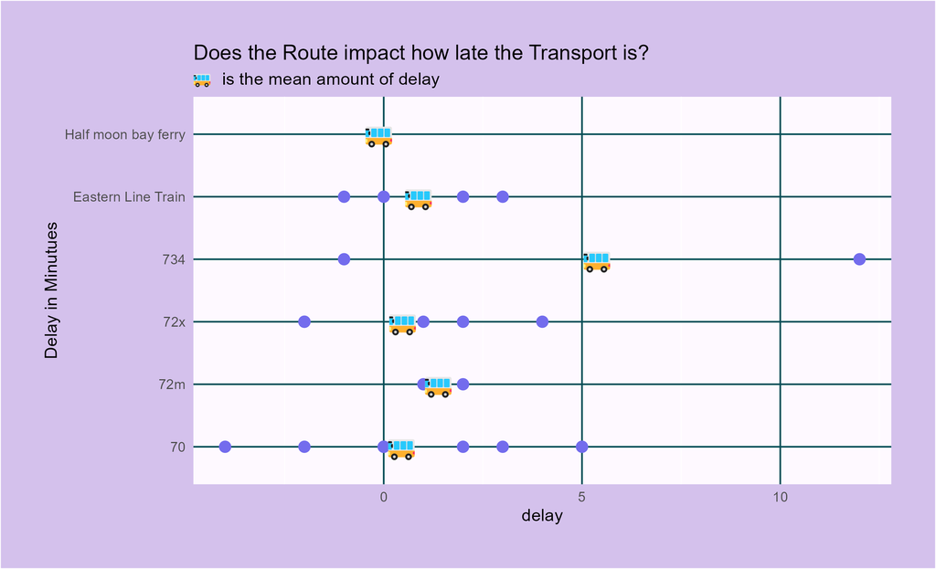

So there is an impact on delay depending on what routes taken.

But most importantly did I enjoy myself?

## Top thoughts on Public Transport

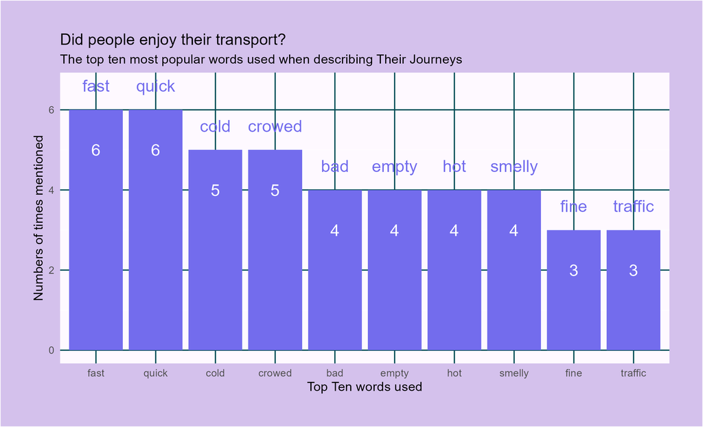

Seems pretty hot or cold… I obviously didn’t have the best of times.